# Assignment 2: CNN-Based Cats vs Dogs Image Classification

**Dataset:** Microsoft Cats vs Dogs

**Models:** CNN from Scratch and Pretrained MobileNetV2

**Training Dataset Sizes:** 1,000, 2,000, and 6,000 Images

**Platform:** Google Colab — TensorFlow/Keras

```python
# Step 2: Download the Cats vs Dogs dataset
# Source: Microsoft Cats vs Dogs dataset on Kaggle

import os

os.makedirs("/content/pawprint_dataset", exist_ok=True)

!pip -q install kaggle
!kaggle datasets download -d shaunthesheep/microsoft-catsvsdogs-dataset -p /content/pawprint_dataset

print("Downloaded files:")
print(os.listdir("/content/pawprint_dataset"))
```

```python
# Step 3: Extract the Cats vs Dogs dataset

import os
import zipfile

pawprint_zip = "/content/pawprint_dataset/microsoft-catsvsdogs-dataset.zip"
pawprint_extract = "/content/pawprint_dataset/extracted_images"

os.makedirs(pawprint_extract, exist_ok=True)

with zipfile.ZipFile(pawprint_zip, "r") as dataset_archive:
    dataset_archive.extractall(pawprint_extract)

# Check the extracted dataset
pawprint_images = os.path.join(pawprint_extract, "PetImages")

print("Dataset extracted successfully!")

for animal in ["Cat", "Dog"]:
    animal_path = os.path.join(pawprint_images, animal)
    print(f"{animal} files: {len(os.listdir(animal_path))}")
```

```
Dataset extracted successfully!
Cat files: 12501
Dog files: 12501
```

```python
# Step 4: Validate the Cats vs Dogs images
# Identify damaged files before preparing the datasets

from PIL import Image
import os
import warnings

pawprint_valid = {}
pawprint_damaged = {}

with warnings.catch_warnings():
    warnings.simplefilter("ignore", UserWarning)

    for animal in ["Cat", "Dog"]:

        animal_folder = os.path.join(pawprint_images, animal)

        valid_paths = []
        damaged_paths = []

        for filename in os.listdir(animal_folder):

            image_path = os.path.join(animal_folder, filename)

            if not os.path.isfile(image_path):
                continue

            try:
                with Image.open(image_path) as image:
                    image.verify()

                valid_paths.append(image_path)

            except Exception:
                damaged_paths.append(image_path)

        pawprint_valid[animal] = sorted(valid_paths)
        pawprint_damaged[animal] = damaged_paths

        print(f"{animal} valid images: {len(valid_paths)}")
        print(f"{animal} damaged images: {len(damaged_paths)}")
        print("-" * 35)

print("Total valid images:",
      sum(len(paths) for paths in pawprint_valid.values()))
```

```
Cat valid images: 12499
Cat damaged images: 2
-----------------------------------
Dog valid images: 12499
Dog damaged images: 2
-----------------------------------
Total valid images: 24998
```

### Image Validation and Cleaning

Before building the classification models, I checked the dataset for damaged or unreadable image files. This step helps prevent errors during image preprocessing and model training. Only successfully validated images will be included in the experiments, while invalid files will be excluded from the sampling process.

### Dataset Sampling and Splitting

To investigate how training sample size affects image classification performance, I created three balanced training datasets containing 1,000, 2,000, and 6,000 images. Each dataset includes equal numbers of cats and dogs.

I reserved 500 images for validation and another 500 images for testing. These two datasets remain unchanged across all experiments so that model performance can be compared consistently.

A fixed random seed was used to make the sampling reproducible. The smaller training datasets were also selected as subsets of the larger datasets, allowing the experiments to focus on the effect of increasing the amount of training data.

```python
# Step 5: Prepare balanced datasets for CNN experiments
# A fixed random seed makes the sampling reproducible

import numpy as np

pawprint_random = np.random.default_rng(42)

# Randomly shuffle valid cat and dog image paths
cat_pool = pawprint_random.permutation(
    pawprint_valid["Cat"]
).tolist()

dog_pool = pawprint_random.permutation(
    pawprint_valid["Dog"]
).tolist()

# Keep validation and testing images separate
pawprint_validation = cat_pool[:250] + dog_pool[:250]

pawprint_testing = cat_pool[250:500] + dog_pool[250:500]

# Reserve the remaining images for training
cat_train_pool = cat_pool[500:]
dog_train_pool = dog_pool[500:]

# Training samples for Questions 1, 2, and 3
pawprint_train_1k = cat_train_pool[:500] + dog_train_pool[:500]

pawprint_train_2k = cat_train_pool[:1000] + dog_train_pool[:1000]

pawprint_train_6k = cat_train_pool[:3000] + dog_train_pool[:3000]

# Display dataset sizes
print("Question 1 training:", len(pawprint_train_1k))
print("Question 2 training:", len(pawprint_train_2k))
print("Question 3 training:", len(pawprint_train_6k))
print("Validation images:", len(pawprint_validation))
print("Testing images:", len(pawprint_testing))

# Check for overlap between datasets
assert set(pawprint_train_6k).isdisjoint(pawprint_validation)
assert set(pawprint_train_6k).isdisjoint(pawprint_testing)
assert set(pawprint_validation).isdisjoint(pawprint_testing)

print("Dataset splitting completed successfully!")
```

```
Question 1 training: 1000
Question 2 training: 2000
Question 3 training: 6000
Validation images: 500
Testing images: 500
Dataset splitting completed successfully!
```

**Interpretation:**

The dataset was successfully divided into three training samples containing 1,000, 2,000, and 6,000 images. Additionally, 500 images were reserved for validation and 500 for testing. The overlap checks confirmed that the training, validation, and testing datasets are independent. Keeping the validation and testing samples fixed will help ensure a fair comparison between the CNN experiments.

### 4. Image Preprocessing

Before training the CNN models, all images will be resized to 128 × 128 pixels and converted to RGB format. Pixel values will be normalized to a range of 0 to 1 to ensure consistent inputs and support stable model training.

```python
# Step 6: Image preprocessing (corrected)
# Supports both JPEG and BMP image formats

import tensorflow as tf

pawprint_image_size = (128, 128)
pawprint_batch_size = 32

def prepare_pawprint_image(image_path, label):

    image_data = tf.io.read_file(image_path)

    # Automatically detect the image format
    image_data = tf.io.decode_image(
        image_data,
        channels=3,
        expand_animations=False
    )

    image_data.set_shape([None, None, 3])

    image_data = tf.image.resize(
        image_data,
        pawprint_image_size
    )

    image_data = tf.cast(image_data, tf.float32) / 255.0

    return image_data, label

print("Image preprocessing corrected successfully!")
```

```
Image preprocessing corrected successfully!
```

### 5. Preparing TensorFlow Datasets

The selected image paths will be converted into TensorFlow datasets for model training and evaluation. The images will be processed in batches of 32, with the training data shuffled to help the CNN learn from different examples during training.

```python
# Step 7: Create TensorFlow datasets
# Labels: Cat = 0, Dog = 1

def create_pawprint_dataset(image_paths, training=False):

    image_labels = [
        0 if os.path.basename(os.path.dirname(path)) == "Cat" else 1
        for path in image_paths
    ]

    dataset = tf.data.Dataset.from_tensor_slices(
        (image_paths, image_labels)
    )

    if training:
        dataset = dataset.shuffle(
            buffer_size=len(image_paths),
            seed=42
        )

    dataset = dataset.map(
        prepare_pawprint_image,
        num_parallel_calls=tf.data.AUTOTUNE
    )

    dataset = dataset.batch(pawprint_batch_size)

    dataset = dataset.prefetch(tf.data.AUTOTUNE)

    return dataset


# Prepare datasets for Question 1
pawprint_train_ds_1k = create_pawprint_dataset(
    pawprint_train_1k,
    training=True
)

pawprint_val_ds = create_pawprint_dataset(
    pawprint_validation
)

pawprint_test_ds = create_pawprint_dataset(
    pawprint_testing
)

print("Question 1 training dataset:", len(pawprint_train_1k), "images")
print("Validation dataset:", len(pawprint_validation), "images")
print("Testing dataset:", len(pawprint_testing), "images")
print("TensorFlow datasets created successfully!")
```

```
Question 1 training dataset: 1000 images
Validation dataset: 500 images
Testing dataset: 500 images
TensorFlow datasets created successfully!
```

## Question 1: CNN Model Using 1,000 Training Images

### Building the CNN Architecture

For the first experiment, I will develop a Convolutional Neural Network (CNN) from scratch to classify cats and dogs. The model will use convolutional and max-pooling layers to extract image features, followed by dense layers for binary classification. The CNN will be trained using 1,000 images and evaluated using the fixed validation and test datasets.

```python
# Step 8: Build a CNN model from scratch

from tensorflow.keras import layers, models

pawprint_cnn_1k = models.Sequential([
    layers.Input(shape=(128, 128, 3)),

    # First convolutional block
    layers.Conv2D(32, (3, 3), activation="relu"),
    layers.MaxPooling2D((2, 2)),

    # Second convolutional block
    layers.Conv2D(64, (3, 3), activation="relu"),
    layers.MaxPooling2D((2, 2)),

    # Third convolutional block
    layers.Conv2D(128, (3, 3), activation="relu"),
    layers.MaxPooling2D((2, 2)),

    # Classification layers
    layers.Flatten(),
    layers.Dense(128, activation="relu"),
    layers.Dropout(0.5),
    layers.Dense(1, activation="sigmoid")
])

# Compile the CNN model
pawprint_cnn_1k.compile(
    optimizer="adam",
    loss="binary_crossentropy",
    metrics=["accuracy"]
)

# Display the model architecture
pawprint_cnn_1k.summary()
```

```
Model: "sequential_1"
```

```
┏━━━━━━━━━━━━━━━━━━━━━━━━━━━━━━━━━┳━━━━━━━━━━━━━━━━━━━━━━━━┳━━━━━━━━━━━━━━━┓
┃ Layer (type)                    ┃ Output Shape           ┃       Param # ┃
┡━━━━━━━━━━━━━━━━━━━━━━━━━━━━━━━━━╇━━━━━━━━━━━━━━━━━━━━━━━━╇━━━━━━━━━━━━━━━┩
│ conv2d_3 (Conv2D)               │ (None, 126, 126, 32)   │           896 │
├─────────────────────────────────┼────────────────────────┼───────────────┤
│ max_pooling2d_3 (MaxPooling2D)  │ (None, 63, 63, 32)     │             0 │
├─────────────────────────────────┼────────────────────────┼───────────────┤
│ conv2d_4 (Conv2D)               │ (None, 61, 61, 64)     │        18,496 │
├─────────────────────────────────┼────────────────────────┼───────────────┤
│ max_pooling2d_4 (MaxPooling2D)  │ (None, 30, 30, 64)     │             0 │
├─────────────────────────────────┼────────────────────────┼───────────────┤
│ conv2d_5 (Conv2D)               │ (None, 28, 28, 128)    │        73,856 │
├─────────────────────────────────┼────────────────────────┼───────────────┤
│ max_pooling2d_5 (MaxPooling2D)  │ (None, 14, 14, 128)    │             0 │
├─────────────────────────────────┼────────────────────────┼───────────────┤
│ flatten_1 (Flatten)             │ (None, 25088)          │             0 │
├─────────────────────────────────┼────────────────────────┼───────────────┤
│ dense_2 (Dense)                 │ (None, 128)            │     3,211,392 │
├─────────────────────────────────┼────────────────────────┼───────────────┤
│ dropout_1 (Dropout)             │ (None, 128)            │             0 │
├─────────────────────────────────┼────────────────────────┼───────────────┤
│ dense_3 (Dense)                 │ (None, 1)              │           129 │
└─────────────────────────────────┴────────────────────────┴───────────────┘
```

```
 Total params: 3,304,769 (12.61 MB)
```

```
 Trainable params: 3,304,769 (12.61 MB)
```

```
 Non-trainable params: 0 (0.00 B)
```

### Model Training

The CNN model will be trained using 1,000 images over 10 epochs, with a batch size of 32. During training, validation accuracy and loss will be monitored to evaluate how well the model generalizes to unseen images.

```python
# Step 9: Train the CNN using 1,000 images

pawprint_history_1k = pawprint_cnn_1k.fit(
    pawprint_train_ds_1k,
    validation_data=pawprint_val_ds,
    epochs=10,
    verbose=1
)

print("Question 1 CNN training completed!")
```

```
32/32 ━━━━━━━━━━━━━━━━━━━━ 43s 1s/step - accuracy: 0.4920 - loss: 0.7360 - val_accuracy: 0.5680 - val_loss: 0.6920
32/32 ━━━━━━━━━━━━━━━━━━━━ 40s 1s/step - accuracy: 0.5350 - loss: 0.6899 - val_accuracy: 0.5540 - val_loss: 0.6867
32/32 ━━━━━━━━━━━━━━━━━━━━ 41s 1s/step - accuracy: 0.5960 - loss: 0.6680 - val_accuracy: 0.5400 - val_loss: 0.6708
32/32 ━━━━━━━━━━━━━━━━━━━━ 43s 1s/step - accuracy: 0.6220 - loss: 0.6445 - val_accuracy: 0.6560 - val_loss: 0.6368
32/32 ━━━━━━━━━━━━━━━━━━━━ 40s 1s/step - accuracy: 0.6560 - loss: 0.6116 - val_accuracy: 0.6260 - val_loss: 0.6374
32/32 ━━━━━━━━━━━━━━━━━━━━ 40s 1s/step - accuracy: 0.7050 - loss: 0.5616 - val_accuracy: 0.6120 - val_loss: 0.6599
32/32 ━━━━━━━━━━━━━━━━━━━━ 43s 1s/step - accuracy: 0.7200 - loss: 0.5601 - val_accuracy: 0.6080 - val_loss: 0.6488
32/32 ━━━━━━━━━━━━━━━━━━━━ 44s 1s/step - accuracy: 0.7460 - loss: 0.4924 - val_accuracy: 0.6280 - val_loss: 0.6629
32/32 ━━━━━━━━━━━━━━━━━━━━ 39s 1s/step - accuracy: 0.8070 - loss: 0.4231 - val_accuracy: 0.6400 - val_loss: 0.6875
32/32 ━━━━━━━━━━━━━━━━━━━━ 41s 1s/step - accuracy: 0.8260 - loss: 0.3736 - val_accuracy: 0.6740 - val_loss: 0.7080
Question 1 CNN training completed!
```

### Model Evaluation

After training the CNN using 1,000 images, I evaluated its performance on the separate test dataset containing 500 images. Test accuracy and loss were used to measure how well the model classified images it had not encountered during training.

```python
# Step 10: Evaluate CNN performance on test images

pawprint_test_loss_1k, pawprint_test_accuracy_1k = pawprint_cnn_1k.evaluate(
    pawprint_test_ds,
    verbose=1
)

print(f"Test Accuracy: {pawprint_test_accuracy_1k * 100:.2f}%")
print(f"Test Loss: {pawprint_test_loss_1k:.4f}")
```

```
16/16 ━━━━━━━━━━━━━━━━━━━━ 6s 381ms/step - accuracy: 0.6920 - loss: 0.6888
Test Accuracy: 69.20%
Test Loss: 0.6888
```

### Results and Interpretation — Question 1

The CNN trained with 1,000 images achieved a test accuracy of 69.20%, showing that it learned to distinguish cats from dogs with moderate success. However, the training accuracy of 82.60% was noticeably higher than the validation accuracy of 67.40%, suggesting some overfitting. Increasing the training sample size may help improve the model's ability to generalize to unseen images.

### Training and Validation Performance

To examine the CNN's performance over 10 epochs, I plotted training and validation accuracy and loss. These graphs help identify learning trends and possible overfitting.

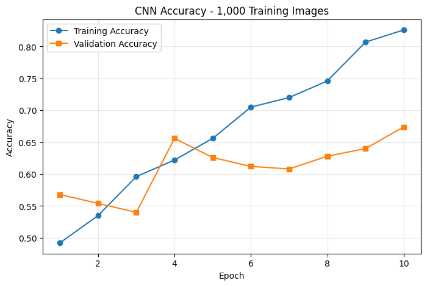

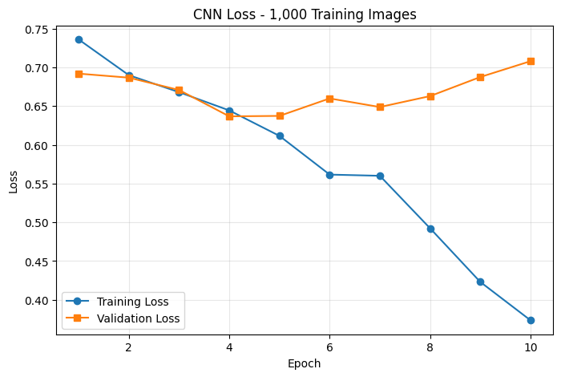

```python
# Step 11: Plot Question 1 accuracy and loss

import matplotlib.pyplot as plt

pawprint_epochs = range(
    1, len(pawprint_history_1k.history["accuracy"]) + 1
)

# Graph 1: Training and validation accuracy
plt.figure(figsize=(8, 5))

plt.plot(
    pawprint_epochs,
    pawprint_history_1k.history["accuracy"],
    marker="o",
    label="Training Accuracy"
)

plt.plot(
    pawprint_epochs,
    pawprint_history_1k.history["val_accuracy"],
    marker="s",
    label="Validation Accuracy"
)

plt.title("CNN Accuracy - 1,000 Training Images")
plt.xlabel("Epoch")
plt.ylabel("Accuracy")
plt.legend()
plt.grid(alpha=0.3)
plt.show()

# Graph 2: Training and validation loss
plt.figure(figsize=(8, 5))

plt.plot(
    pawprint_epochs,
    pawprint_history_1k.history["loss"],
    marker="o",
    label="Training Loss"
)

plt.plot(
    pawprint_epochs,
    pawprint_history_1k.history["val_loss"],
    marker="s",
    label="Validation Loss"
)

plt.title("CNN Loss - 1,000 Training Images")
plt.xlabel("Epoch")
plt.ylabel("Loss")
plt.legend()
plt.grid(alpha=0.3)
plt.show()
```

**Interpretation:**

The training accuracy increased throughout the 10 epochs, reaching 82.60%, while validation accuracy reached 67.40%. Training loss decreased, but validation loss began increasing after the earlier epochs. This suggests that the CNN started overfitting the training data. The model achieved a test accuracy of 69.20%, indicating moderate classification performance.

## Question 2: CNN Model Using 2,000 Training Images

In this experiment, the CNN is trained using 2,000 images, with an equal number of cats and dogs. The validation and testing datasets remain unchanged from Question 1 to support a fair comparison.

```python
# Step 12: Prepare the 2,000-image training dataset

pawprint_train_ds_2k = create_pawprint_dataset(
    pawprint_train_2k,
    training=True
)

pawprint_val_ds = create_pawprint_dataset(
    pawprint_validation
)

pawprint_test_ds = create_pawprint_dataset(
    pawprint_testing
)

print("Training images:", len(pawprint_train_2k))
print("Validation images:", len(pawprint_validation))
print("Testing images:", len(pawprint_testing))
```

```
Training images: 2000
Validation images: 500
Testing images: 500
```

### CNN Model Architecture

The CNN architecture from Question 1 is reused with a larger training dataset of 2,000 images. The model starts with newly initialized weights to examine how training dataset size influences classification performance.

```python
# Step 13: Build a fresh CNN for 2,000 training images

pawprint_cnn_2k = tf.keras.Sequential([
    tf.keras.layers.Input(shape=(128, 128, 3)),

    tf.keras.layers.Conv2D(32, (3, 3), activation="relu"),
    tf.keras.layers.MaxPooling2D((2, 2)),

    tf.keras.layers.Conv2D(64, (3, 3), activation="relu"),
    tf.keras.layers.MaxPooling2D((2, 2)),

    tf.keras.layers.Conv2D(128, (3, 3), activation="relu"),
    tf.keras.layers.MaxPooling2D((2, 2)),

    tf.keras.layers.Flatten(),
    tf.keras.layers.Dense(128, activation="relu"),
    tf.keras.layers.Dropout(0.5),
    tf.keras.layers.Dense(1, activation="sigmoid")
])

pawprint_cnn_2k.compile(
    optimizer="adam",
    loss="binary_crossentropy",
    metrics=["accuracy"]
)

pawprint_cnn_2k.summary()
```

[output not shown]

[output not shown]

```
 Total params: 3,304,769 (12.61 MB)
```

```
 Trainable params: 3,304,769 (12.61 MB)
```

```
 Non-trainable params: 0 (0.00 B)
```

### CNN Model Training

The CNN is trained using 2,000 images with early stopping to limit overfitting. The best model weights are restored based on validation loss, helping the model retain its strongest validation performance.

```python
# Step 14: Train the CNN with early stopping

pawprint_early_stop_2k = tf.keras.callbacks.EarlyStopping(
    monitor="val_loss",
    patience=3,
    restore_best_weights=True
)

pawprint_history_2k = pawprint_cnn_2k.fit(
    pawprint_train_ds_2k,
    validation_data=pawprint_val_ds,
    epochs=15,
    callbacks=[pawprint_early_stop_2k]
)
```

```
63/63 ━━━━━━━━━━━━━━━━━━━━ 8s 80ms/step - accuracy: 0.5190 - loss: 0.7264 - val_accuracy: 0.6380 - val_loss: 0.6848
63/63 ━━━━━━━━━━━━━━━━━━━━ 2s 38ms/step - accuracy: 0.5675 - loss: 0.6827 - val_accuracy: 0.5620 - val_loss: 0.6523
63/63 ━━━━━━━━━━━━━━━━━━━━ 3s 37ms/step - accuracy: 0.6320 - loss: 0.6592 - val_accuracy: 0.6180 - val_loss: 0.6468
63/63 ━━━━━━━━━━━━━━━━━━━━ 2s 34ms/step - accuracy: 0.6780 - loss: 0.5949 - val_accuracy: 0.6840 - val_loss: 0.5914
63/63 ━━━━━━━━━━━━━━━━━━━━ 2s 37ms/step - accuracy: 0.7265 - loss: 0.5498 - val_accuracy: 0.6780 - val_loss: 0.5758
63/63 ━━━━━━━━━━━━━━━━━━━━ 3s 38ms/step - accuracy: 0.7685 - loss: 0.4789 - val_accuracy: 0.6940 - val_loss: 0.6224
63/63 ━━━━━━━━━━━━━━━━━━━━ 2s 34ms/step - accuracy: 0.8160 - loss: 0.3954 - val_accuracy: 0.7040 - val_loss: 0.6080
63/63 ━━━━━━━━━━━━━━━━━━━━ 3s 34ms/step - accuracy: 0.8520 - loss: 0.3377 - val_accuracy: 0.7100 - val_loss: 0.6586
```

```python
# Step 15: Evaluate the CNN using 500 test images

pawprint_test_loss_2k, pawprint_test_accuracy_2k = pawprint_cnn_2k.evaluate(
    pawprint_test_ds
)

print(f"Test Accuracy: {pawprint_test_accuracy_2k * 100:.2f}%")
print(f"Test Loss: {pawprint_test_loss_2k:.4f}")
```

```
16/16 ━━━━━━━━━━━━━━━━━━━━ 1s 56ms/step - accuracy: 0.7120 - loss: 0.5902
Test Accuracy: 71.20%
Test Loss: 0.5902
```

### Training and Validation Performance

The following graphs illustrate how the CNN's accuracy and loss changed during training with 2,000 images.

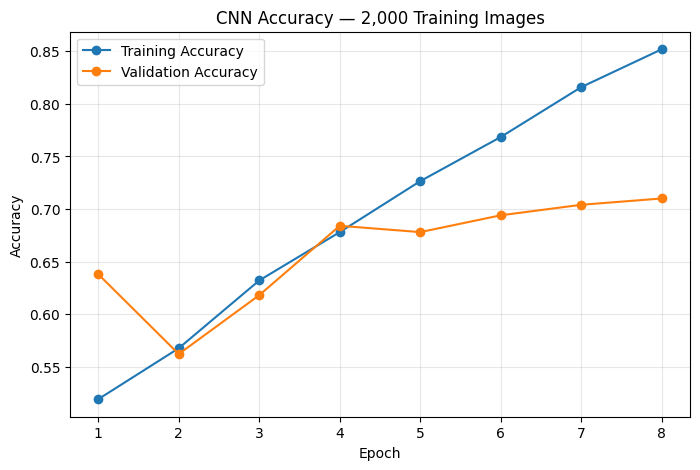

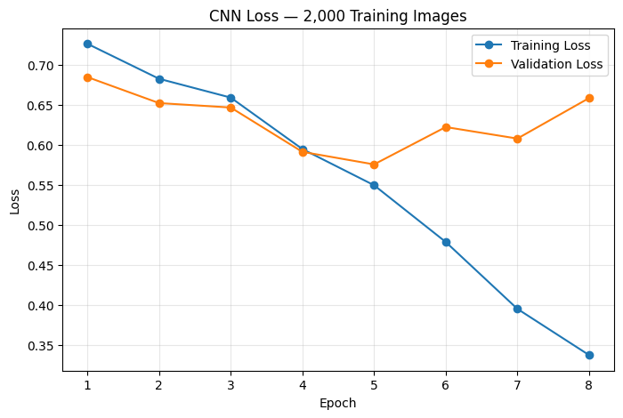

```python
# Step 16: Plot accuracy and loss for Question 2

import matplotlib.pyplot as plt

pawprint_epochs_2k = range(
    1, len(pawprint_history_2k.history["accuracy"]) + 1
)

plt.figure(figsize=(8, 5))
plt.plot(pawprint_epochs_2k, pawprint_history_2k.history["accuracy"],
         marker="o", label="Training Accuracy")
plt.plot(pawprint_epochs_2k, pawprint_history_2k.history["val_accuracy"],
         marker="o", label="Validation Accuracy")

plt.title("CNN Accuracy — 2,000 Training Images")
plt.xlabel("Epoch")
plt.ylabel("Accuracy")
plt.legend()
plt.grid(alpha=0.3)
plt.show()

plt.figure(figsize=(8, 5))
plt.plot(pawprint_epochs_2k, pawprint_history_2k.history["loss"],
         marker="o", label="Training Loss")
plt.plot(pawprint_epochs_2k, pawprint_history_2k.history["val_loss"],
         marker="o", label="Validation Loss")

plt.title("CNN Loss — 2,000 Training Images")
plt.xlabel("Epoch")
plt.ylabel("Loss")
plt.legend()
plt.grid(alpha=0.3)
plt.show()
```

### Results and Interpretation — Question 2

The CNN trained on 2,000 images achieved a test accuracy of **71.20%**, compared with **69.20%** in Question 1. This represents an improvement of 2 percentage points. The test loss also decreased from 0.6888 to 0.5902, indicating better performance on unseen images.

The training graphs show signs of overfitting as training accuracy continued to increase while validation loss began rising. Early stopping helped limit this issue by restoring the model weights from the epoch with the lowest validation loss.

Overall, Question 2 achieved better test performance, although the improvement may be influenced by both the larger training dataset and the use of early stopping.

## Question 3: CNN Model Using 6,000 Training Images

In this experiment, the training dataset is increased to 6,000 images, consisting of 3,000 cats and 3,000 dogs. The validation and testing datasets remain unchanged to allow comparison with the previous experiments.

### CNN Model Architecture

The same CNN architecture is used with 6,000 training images. Keeping the model structure consistent helps examine how increasing the training dataset affects classification performance.

```python
# Step 19: Build a fresh CNN for 6,000 training images

pawprint_cnn_6k = tf.keras.Sequential([
    tf.keras.layers.Input(shape=(128, 128, 3)),

    tf.keras.layers.Conv2D(32, (3, 3), activation="relu"),
    tf.keras.layers.MaxPooling2D((2, 2)),

    tf.keras.layers.Conv2D(64, (3, 3), activation="relu"),
    tf.keras.layers.MaxPooling2D((2, 2)),

    tf.keras.layers.Conv2D(128, (3, 3), activation="relu"),
    tf.keras.layers.MaxPooling2D((2, 2)),

    tf.keras.layers.Flatten(),
    tf.keras.layers.Dense(128, activation="relu"),
    tf.keras.layers.Dropout(0.5),
    tf.keras.layers.Dense(1, activation="sigmoid")
])

pawprint_cnn_6k.compile(
    optimizer="adam",
    loss="binary_crossentropy",
    metrics=["accuracy"]
)

pawprint_cnn_6k.summary()
```

```
Model: "sequential_3"
```

```
┏━━━━━━━━━━━━━━━━━━━━━━━━━━━━━━━━━┳━━━━━━━━━━━━━━━━━━━━━━━━┳━━━━━━━━━━━━━━━┓
┃ Layer (type)                    ┃ Output Shape           ┃       Param # ┃
┡━━━━━━━━━━━━━━━━━━━━━━━━━━━━━━━━━╇━━━━━━━━━━━━━━━━━━━━━━━━╇━━━━━━━━━━━━━━━┩
│ conv2d_9 (Conv2D)               │ (None, 126, 126, 32)   │           896 │
├─────────────────────────────────┼────────────────────────┼───────────────┤
│ max_pooling2d_9 (MaxPooling2D)  │ (None, 63, 63, 32)     │             0 │
├─────────────────────────────────┼────────────────────────┼───────────────┤
│ conv2d_10 (Conv2D)              │ (None, 61, 61, 64)     │        18,496 │
├─────────────────────────────────┼────────────────────────┼───────────────┤
│ max_pooling2d_10 (MaxPooling2D) │ (None, 30, 30, 64)     │             0 │
├─────────────────────────────────┼────────────────────────┼───────────────┤
│ conv2d_11 (Conv2D)              │ (None, 28, 28, 128)    │        73,856 │
├─────────────────────────────────┼────────────────────────┼───────────────┤
│ max_pooling2d_11 (MaxPooling2D) │ (None, 14, 14, 128)    │             0 │
├─────────────────────────────────┼────────────────────────┼───────────────┤
│ flatten_3 (Flatten)             │ (None, 25088)          │             0 │
├─────────────────────────────────┼────────────────────────┼───────────────┤
│ dense_6 (Dense)                 │ (None, 128)            │     3,211,392 │
├─────────────────────────────────┼────────────────────────┼───────────────┤
│ dropout_3 (Dropout)             │ (None, 128)            │             0 │
├─────────────────────────────────┼────────────────────────┼───────────────┤
│ dense_7 (Dense)                 │ (None, 1)              │           129 │
└─────────────────────────────────┴────────────────────────┴───────────────┘
```

```
 Total params: 3,304,769 (12.61 MB)
```

```
 Trainable params: 3,304,769 (12.61 MB)
```

```
 Non-trainable params: 0 (0.00 B)
```

```python
# Step 22: Select exactly 6,000 TensorFlow-compatible images

def pawprint_tf_compatible(path):
    try:
        image_bytes = tf.io.read_file(path)
        image = tf.io.decode_image(
            image_bytes,
            channels=3,
            expand_animations=False
        )
        return image.shape[-1] == 3
    except (tf.errors.OpError, ValueError):
        return False

pawprint_train_6k_clean = []

for animal in ["Cat", "Dog"]:
    original_paths = [
        path for path in pawprint_train_6k
        if os.path.basename(os.path.dirname(path)) == animal
    ]

    reserved_paths = set(
        pawprint_validation + pawprint_testing
    )

    candidates = original_paths + [
        path for path in pawprint_valid[animal]
        if path not in reserved_paths
        and path not in pawprint_train_6k
    ]

    selected = []

    for path in candidates:
        if pawprint_tf_compatible(path):
            selected.append(path)

        if len(selected) == 3000:
            break

    pawprint_train_6k_clean.extend(selected)

pawprint_train_ds_6k = create_pawprint_dataset(
    pawprint_train_6k_clean,
    training=True
)

print("Training images:", len(pawprint_train_6k_clean))
print("Cats:", sum("Cat" in path for path in pawprint_train_6k_clean))
print("Dogs:", sum("Dog" in path for path in pawprint_train_6k_clean))
```

```
Training images: 6000
Cats: 3000
Dogs: 3000
```

```python
# Step 23: Train Question 3 with 6,000 valid images

pawprint_cnn_6k = tf.keras.models.clone_model(pawprint_cnn_6k)

pawprint_cnn_6k.compile(
    optimizer="adam",
    loss="binary_crossentropy",
    metrics=["accuracy"]
)

pawprint_early_stop_6k = tf.keras.callbacks.EarlyStopping(
    monitor="val_loss",
    patience=3,
    restore_best_weights=True
)

pawprint_history_6k = pawprint_cnn_6k.fit(
    pawprint_train_ds_6k,
    validation_data=pawprint_val_ds,
    epochs=15,
    callbacks=[pawprint_early_stop_6k]
)
```

```
188/188 ━━━━━━━━━━━━━━━━━━━━ 12s 45ms/step - accuracy: 0.5493 - loss: 0.6865 - val_accuracy: 0.6300 - val_loss: 0.6503
188/188 ━━━━━━━━━━━━━━━━━━━━ 6s 31ms/step - accuracy: 0.6300 - loss: 0.6475 - val_accuracy: 0.6680 - val_loss: 0.5945
188/188 ━━━━━━━━━━━━━━━━━━━━ 6s 30ms/step - accuracy: 0.7078 - loss: 0.5670 - val_accuracy: 0.7320 - val_loss: 0.5375
188/188 ━━━━━━━━━━━━━━━━━━━━ 10s 30ms/step - accuracy: 0.7500 - loss: 0.5103 - val_accuracy: 0.7600 - val_loss: 0.4771
188/188 ━━━━━━━━━━━━━━━━━━━━ 6s 30ms/step - accuracy: 0.7918 - loss: 0.4474 - val_accuracy: 0.7760 - val_loss: 0.4615
188/188 ━━━━━━━━━━━━━━━━━━━━ 6s 29ms/step - accuracy: 0.8302 - loss: 0.3832 - val_accuracy: 0.7520 - val_loss: 0.4791
188/188 ━━━━━━━━━━━━━━━━━━━━ 5s 29ms/step - accuracy: 0.8588 - loss: 0.3232 - val_accuracy: 0.7880 - val_loss: 0.4530
188/188 ━━━━━━━━━━━━━━━━━━━━ 6s 30ms/step - accuracy: 0.8928 - loss: 0.2553 - val_accuracy: 0.8020 - val_loss: 0.4677
188/188 ━━━━━━━━━━━━━━━━━━━━ 6s 29ms/step - accuracy: 0.9158 - loss: 0.2117 - val_accuracy: 0.7920 - val_loss: 0.5307
188/188 ━━━━━━━━━━━━━━━━━━━━ 6s 30ms/step - accuracy: 0.9373 - loss: 0.1559 - val_accuracy: 0.8100 - val_loss: 0.6216
```

```python
# Step 24: Evaluate the CNN trained on 6,000 images

pawprint_test_loss_6k, pawprint_test_accuracy_6k = pawprint_cnn_6k.evaluate(
    pawprint_test_ds
)

print(f"Test Accuracy: {pawprint_test_accuracy_6k * 100:.2f}%")
print(f"Test Loss: {pawprint_test_loss_6k:.4f}")
```

```
16/16 ━━━━━━━━━━━━━━━━━━━━ 1s 42ms/step - accuracy: 0.7960 - loss: 0.4339
Test Accuracy: 79.60%
Test Loss: 0.4339
```

### Training and Validation Performance

The following graphs illustrate the changes in training and validation accuracy and loss during the CNN experiment with 6,000 images.

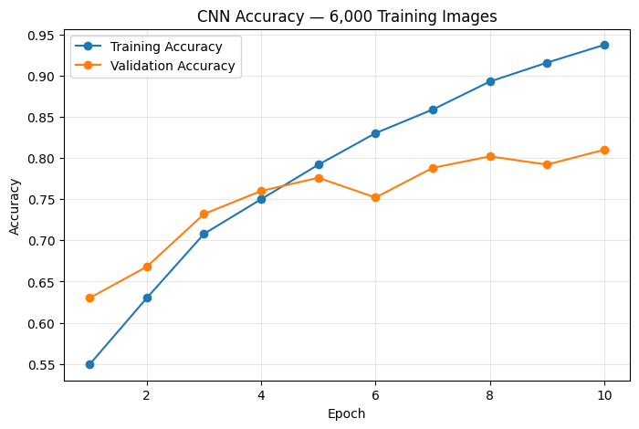

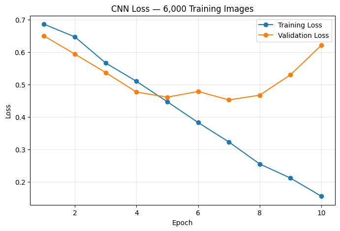

```python
# Step 25: Plot accuracy and loss for Question 3

import matplotlib.pyplot as plt

pawprint_epochs_6k = range(
    1, len(pawprint_history_6k.history["accuracy"]) + 1
)

plt.figure(figsize=(8, 5))
plt.plot(pawprint_epochs_6k, pawprint_history_6k.history["accuracy"],
         marker="o", label="Training Accuracy")
plt.plot(pawprint_epochs_6k, pawprint_history_6k.history["val_accuracy"],
         marker="o", label="Validation Accuracy")

plt.title("CNN Accuracy — 6,000 Training Images")
plt.xlabel("Epoch")
plt.ylabel("Accuracy")
plt.legend()
plt.grid(alpha=0.3)
plt.show()

plt.figure(figsize=(8, 5))
plt.plot(pawprint_epochs_6k, pawprint_history_6k.history["loss"],
         marker="o", label="Training Loss")
plt.plot(pawprint_epochs_6k, pawprint_history_6k.history["val_loss"],
         marker="o", label="Validation Loss")

plt.title("CNN Loss — 6,000 Training Images")
plt.xlabel("Epoch")
plt.ylabel("Loss")
plt.legend()
plt.grid(alpha=0.3)
plt.show()
```

### Results and Interpretation — Question 3

The CNN trained using 6,000 images achieved a test accuracy of **79.60%** and a test loss of **0.4339**. This is an improvement over Question 2, which achieved 71.20% accuracy using 2,000 images.

The graphs show that training accuracy increased steadily, while validation accuracy also improved. However, validation loss began increasing after Epoch 7, suggesting some overfitting. Early stopping helped by restoring the weights from the epoch with the lowest validation loss.

Overall, the larger training dataset produced better classification performance in this experiment.

## Question 4: Image Classification Using a Pretrained CNN

This experiment uses MobileNetV2, a convolutional neural network pretrained on ImageNet. Transfer learning is applied to classify cats and dogs using training datasets of 1,000, 2,000, and 6,000 images. The same validation and testing datasets are retained to compare performance with the CNN models trained from scratch.

```python
# Step 27: Import MobileNetV2 for transfer learning

from tensorflow.keras.applications import MobileNetV2
from tensorflow.keras.applications.mobilenet_v2 import preprocess_input

print("MobileNetV2 imported successfully.")
```

```
MobileNetV2 imported successfully.
```

```python
# Step 28: Prepare image datasets for MobileNetV2

def prepare_pawprint_pretrained(image, label):
    image = tf.cast(image, tf.float32)
    image = (image * 2.0) - 1.0
    return image, label

pawprint_pretrained_val_ds = pawprint_val_ds.map(
    prepare_pawprint_pretrained
)

pawprint_pretrained_test_ds = pawprint_test_ds.map(
    prepare_pawprint_pretrained
)

pawprint_pretrained_train_ds_1k = create_pawprint_dataset(
    pawprint_train_1k,
    training=True
).map(prepare_pawprint_pretrained)

pawprint_pretrained_train_ds_2k = pawprint_train_ds_2k.map(
    prepare_pawprint_pretrained
)

pawprint_pretrained_train_ds_6k = pawprint_train_ds_6k.map(
    prepare_pawprint_pretrained
)

print("MobileNetV2 datasets prepared successfully.")
```

```
MobileNetV2 datasets prepared successfully.
```

```python
# Step 29: Build MobileNetV2 for 1,000 training images

pawprint_base_1k = MobileNetV2(
    weights="imagenet",
    include_top=False,
    input_shape=(128, 128, 3)
)

pawprint_base_1k.trainable = False

pawprint_pretrained_cnn_1k = tf.keras.Sequential([
    pawprint_base_1k,
    tf.keras.layers.GlobalAveragePooling2D(),
    tf.keras.layers.Dense(128, activation="relu"),
    tf.keras.layers.Dropout(0.5),
    tf.keras.layers.Dense(1, activation="sigmoid")
])

pawprint_pretrained_cnn_1k.compile(
    optimizer=tf.keras.optimizers.Adam(learning_rate=0.0001),
    loss="binary_crossentropy",
    metrics=["accuracy"]
)

pawprint_pretrained_cnn_1k.summary()
```

```
Downloading data from https://storage.googleapis.com/tensorflow/keras-applications/mobilenet_v2/mobilenet_v2_weights_tf_dim_ordering_tf_kernels_1.0_128_no_top.h5
9406464/9406464 ━━━━━━━━━━━━━━━━━━━━ 0s 0us/step
```

```
Model: "sequential_4"
```

```
┏━━━━━━━━━━━━━━━━━━━━━━━━━━━━━━━━━┳━━━━━━━━━━━━━━━━━━━━━━━━┳━━━━━━━━━━━━━━━┓
┃ Layer (type)                    ┃ Output Shape           ┃       Param # ┃
┡━━━━━━━━━━━━━━━━━━━━━━━━━━━━━━━━━╇━━━━━━━━━━━━━━━━━━━━━━━━╇━━━━━━━━━━━━━━━┩
│ mobilenetv2_1.00_128            │ (None, 4, 4, 1280)     │     2,257,984 │
│ (Functional)                    │                        │               │
├─────────────────────────────────┼────────────────────────┼───────────────┤
│ global_average_pooling2d        │ (None, 1280)           │             0 │
│ (GlobalAveragePooling2D)        │                        │               │
├─────────────────────────────────┼────────────────────────┼───────────────┤
│ dense_8 (Dense)                 │ (None, 128)            │       163,968 │
├─────────────────────────────────┼────────────────────────┼───────────────┤
│ dropout_4 (Dropout)             │ (None, 128)            │             0 │
├─────────────────────────────────┼────────────────────────┼───────────────┤
│ dense_9 (Dense)                 │ (None, 1)              │           129 │
└─────────────────────────────────┴────────────────────────┴───────────────┘
```

```
 Total params: 2,422,081 (9.24 MB)
```

```
 Trainable params: 164,097 (641.00 KB)
```

```
 Non-trainable params: 2,257,984 (8.61 MB)
```

```python
# Step 30: Train pretrained MobileNetV2 with 1,000 images

pawprint_early_stop_pretrained_1k = tf.keras.callbacks.EarlyStopping(
    monitor="val_loss",
    patience=3,
    restore_best_weights=True
)

pawprint_history_pretrained_1k = pawprint_pretrained_cnn_1k.fit(
    pawprint_pretrained_train_ds_1k,
    validation_data=pawprint_pretrained_val_ds,
    epochs=15,
    callbacks=[pawprint_early_stop_pretrained_1k]
)
```

```
32/32 ━━━━━━━━━━━━━━━━━━━━ 22s 381ms/step - accuracy: 0.7070 - loss: 0.5879 - val_accuracy: 0.9360 - val_loss: 0.2593
32/32 ━━━━━━━━━━━━━━━━━━━━ 2s 52ms/step - accuracy: 0.9080 - loss: 0.2434 - val_accuracy: 0.9500 - val_loss: 0.1656
32/32 ━━━━━━━━━━━━━━━━━━━━ 2s 53ms/step - accuracy: 0.9500 - loss: 0.1650 - val_accuracy: 0.9620 - val_loss: 0.1346
32/32 ━━━━━━━━━━━━━━━━━━━━ 2s 47ms/step - accuracy: 0.9510 - loss: 0.1370 - val_accuracy: 0.9560 - val_loss: 0.1207
32/32 ━━━━━━━━━━━━━━━━━━━━ 2s 47ms/step - accuracy: 0.9580 - loss: 0.1231 - val_accuracy: 0.9580 - val_loss: 0.1121
32/32 ━━━━━━━━━━━━━━━━━━━━ 2s 47ms/step - accuracy: 0.9600 - loss: 0.1122 - val_accuracy: 0.9600 - val_loss: 0.1071
32/32 ━━━━━━━━━━━━━━━━━━━━ 2s 52ms/step - accuracy: 0.9660 - loss: 0.0923 - val_accuracy: 0.9620 - val_loss: 0.1043
32/32 ━━━━━━━━━━━━━━━━━━━━ 2s 48ms/step - accuracy: 0.9720 - loss: 0.0806 - val_accuracy: 0.9580 - val_loss: 0.1013
32/32 ━━━━━━━━━━━━━━━━━━━━ 3s 48ms/step - accuracy: 0.9820 - loss: 0.0670 - val_accuracy: 0.9620 - val_loss: 0.0990
32/32 ━━━━━━━━━━━━━━━━━━━━ 2s 47ms/step - accuracy: 0.9810 - loss: 0.0615 - val_accuracy: 0.9600 - val_loss: 0.0984
32/32 ━━━━━━━━━━━━━━━━━━━━ 1s 44ms/step - accuracy: 0.9880 - loss: 0.0589 - val_accuracy: 0.9600 - val_loss: 0.1006
32/32 ━━━━━━━━━━━━━━━━━━━━ 1s 44ms/step - accuracy: 0.9850 - loss: 0.0552 - val_accuracy: 0.9600 - val_loss: 0.1005
32/32 ━━━━━━━━━━━━━━━━━━━━ 2s 49ms/step - accuracy: 0.9890 - loss: 0.0493 - val_accuracy: 0.9620 - val_loss: 0.1005
```

```python
# Step 31: Evaluate pretrained MobileNetV2 with 1,000 images

pawprint_pretrained_loss_1k, pawprint_pretrained_accuracy_1k = (
    pawprint_pretrained_cnn_1k.evaluate(pawprint_pretrained_test_ds)
)

print(f"Test Accuracy: {pawprint_pretrained_accuracy_1k * 100:.2f}%")
print(f"Test Loss: {pawprint_pretrained_loss_1k:.4f}")
```

```
16/16 ━━━━━━━━━━━━━━━━━━━━ 0s 28ms/step - accuracy: 0.9640 - loss: 0.1055
Test Accuracy: 96.40%
Test Loss: 0.1055
```

### Training and Validation Performance — 1,000 Images

The following graphs show the accuracy and loss of the pretrained MobileNetV2 model during training with 1,000 images.

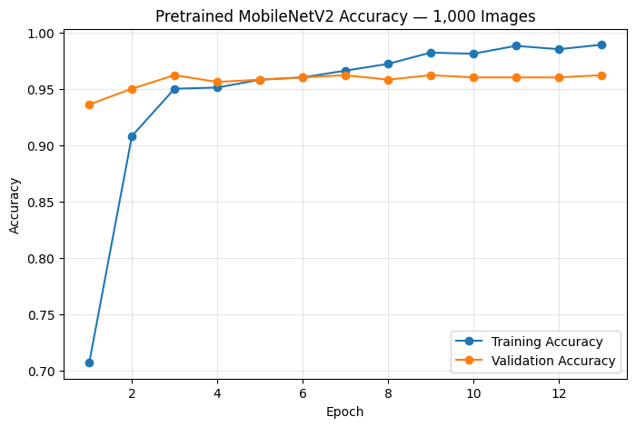

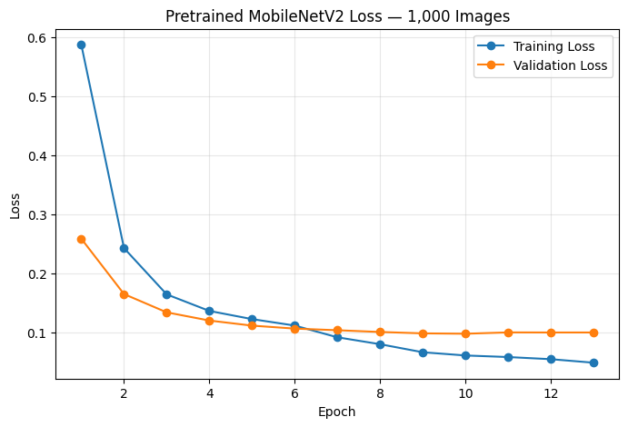

```python
# Step 32: Plot pretrained MobileNetV2 training results

pawprint_epochs_pretrained_1k = range(
    1, len(pawprint_history_pretrained_1k.history["accuracy"]) + 1
)

plt.figure(figsize=(8, 5))
plt.plot(
    pawprint_epochs_pretrained_1k,
    pawprint_history_pretrained_1k.history["accuracy"],
    marker="o",
    label="Training Accuracy"
)
plt.plot(
    pawprint_epochs_pretrained_1k,
    pawprint_history_pretrained_1k.history["val_accuracy"],
    marker="o",
    label="Validation Accuracy"
)

plt.title("Pretrained MobileNetV2 Accuracy — 1,000 Images")
plt.xlabel("Epoch")
plt.ylabel("Accuracy")
plt.legend()
plt.grid(alpha=0.3)
plt.show()

plt.figure(figsize=(8, 5))
plt.plot(
    pawprint_epochs_pretrained_1k,
    pawprint_history_pretrained_1k.history["loss"],
    marker="o",
    label="Training Loss"
)
plt.plot(
    pawprint_epochs_pretrained_1k,
    pawprint_history_pretrained_1k.history["val_loss"],
    marker="o",
    label="Validation Loss"
)

plt.title("Pretrained MobileNetV2 Loss — 1,000 Images")
plt.xlabel("Epoch")
plt.ylabel("Loss")
plt.legend()
plt.grid(alpha=0.3)
plt.show()
```

### Results and Interpretation — Pretrained CNN with 1,000 Images

The pretrained MobileNetV2 model achieved a test accuracy of **96.40%** and a test loss of **0.1055** using 1,000 training images. In comparison, the CNN trained from scratch using the same number of images achieved 69.20% test accuracy.

The pretrained model performed substantially better, with an improvement of 27.20 percentage points. This suggests that features learned from the ImageNet dataset were useful for distinguishing cats from dogs.

The training and validation results also showed strong classification performance. Early stopping selected the weights from Epoch 10, which had the lowest validation loss.

Overall, transfer learning provided a significant performance advantage in this experiment, even with a relatively small training dataset.

### Experiment 2: Pretrained MobileNetV2 Using 2,000 Training Images

In this experiment, the same pretrained MobileNetV2 architecture is used with 2,000 training images. A new classification head is trained while the pretrained feature-extraction layers remain frozen. The validation and testing datasets remain unchanged.

```python
# Step 34: Build MobileNetV2 for 2,000 training images

pawprint_base_2k = MobileNetV2(
    weights="imagenet",
    include_top=False,
    input_shape=(128, 128, 3)
)

pawprint_base_2k.trainable = False

pawprint_pretrained_cnn_2k = tf.keras.Sequential([
    pawprint_base_2k,
    tf.keras.layers.GlobalAveragePooling2D(),
    tf.keras.layers.Dense(128, activation="relu"),
    tf.keras.layers.Dropout(0.5),
    tf.keras.layers.Dense(1, activation="sigmoid")
])

pawprint_pretrained_cnn_2k.compile(
    optimizer=tf.keras.optimizers.Adam(learning_rate=0.0001),
    loss="binary_crossentropy",
    metrics=["accuracy"]
)

pawprint_pretrained_cnn_2k.summary()
```

```
Model: "sequential_5"
```

```
┏━━━━━━━━━━━━━━━━━━━━━━━━━━━━━━━━━┳━━━━━━━━━━━━━━━━━━━━━━━━┳━━━━━━━━━━━━━━━┓
┃ Layer (type)                    ┃ Output Shape           ┃       Param # ┃
┡━━━━━━━━━━━━━━━━━━━━━━━━━━━━━━━━━╇━━━━━━━━━━━━━━━━━━━━━━━━╇━━━━━━━━━━━━━━━┩
│ mobilenetv2_1.00_128            │ (None, 4, 4, 1280)     │     2,257,984 │
│ (Functional)                    │                        │               │
├─────────────────────────────────┼────────────────────────┼───────────────┤
│ global_average_pooling2d_1      │ (None, 1280)           │             0 │
│ (GlobalAveragePooling2D)        │                        │               │
├─────────────────────────────────┼────────────────────────┼───────────────┤
│ dense_10 (Dense)                │ (None, 128)            │       163,968 │
├─────────────────────────────────┼────────────────────────┼───────────────┤
│ dropout_5 (Dropout)             │ (None, 128)            │             0 │
├─────────────────────────────────┼────────────────────────┼───────────────┤
│ dense_11 (Dense)                │ (None, 1)              │           129 │
└─────────────────────────────────┴────────────────────────┴───────────────┘
```

```
 Total params: 2,422,081 (9.24 MB)
```

```
 Trainable params: 164,097 (641.00 KB)
```

```
 Non-trainable params: 2,257,984 (8.61 MB)
```

```python
# Step 35: Train pretrained MobileNetV2 with 2,000 images

pawprint_early_stop_pretrained_2k = tf.keras.callbacks.EarlyStopping(
    monitor="val_loss",
    patience=3,
    restore_best_weights=True
)

pawprint_history_pretrained_2k = pawprint_pretrained_cnn_2k.fit(
    pawprint_pretrained_train_ds_2k,
    validation_data=pawprint_pretrained_val_ds,
    epochs=15,
    callbacks=[pawprint_early_stop_pretrained_2k]
)
```

```
63/63 ━━━━━━━━━━━━━━━━━━━━ 19s 187ms/step - accuracy: 0.7955 - loss: 0.4255 - val_accuracy: 0.9520 - val_loss: 0.1514
63/63 ━━━━━━━━━━━━━━━━━━━━ 2s 39ms/step - accuracy: 0.9295 - loss: 0.1819 - val_accuracy: 0.9620 - val_loss: 0.1046
63/63 ━━━━━━━━━━━━━━━━━━━━ 3s 41ms/step - accuracy: 0.9520 - loss: 0.1361 - val_accuracy: 0.9700 - val_loss: 0.0901
63/63 ━━━━━━━━━━━━━━━━━━━━ 2s 38ms/step - accuracy: 0.9695 - loss: 0.0993 - val_accuracy: 0.9700 - val_loss: 0.0814
63/63 ━━━━━━━━━━━━━━━━━━━━ 2s 37ms/step - accuracy: 0.9705 - loss: 0.0881 - val_accuracy: 0.9760 - val_loss: 0.0743
63/63 ━━━━━━━━━━━━━━━━━━━━ 2s 38ms/step - accuracy: 0.9765 - loss: 0.0749 - val_accuracy: 0.9800 - val_loss: 0.0706
63/63 ━━━━━━━━━━━━━━━━━━━━ 2s 37ms/step - accuracy: 0.9765 - loss: 0.0696 - val_accuracy: 0.9760 - val_loss: 0.0684
63/63 ━━━━━━━━━━━━━━━━━━━━ 2s 38ms/step - accuracy: 0.9745 - loss: 0.0688 - val_accuracy: 0.9780 - val_loss: 0.0664
63/63 ━━━━━━━━━━━━━━━━━━━━ 3s 38ms/step - accuracy: 0.9830 - loss: 0.0556 - val_accuracy: 0.9800 - val_loss: 0.0654
63/63 ━━━━━━━━━━━━━━━━━━━━ 2s 39ms/step - accuracy: 0.9845 - loss: 0.0547 - val_accuracy: 0.9780 - val_loss: 0.0643
63/63 ━━━━━━━━━━━━━━━━━━━━ 2s 39ms/step - accuracy: 0.9885 - loss: 0.0409 - val_accuracy: 0.9800 - val_loss: 0.0665
63/63 ━━━━━━━━━━━━━━━━━━━━ 2s 36ms/step - accuracy: 0.9885 - loss: 0.0402 - val_accuracy: 0.9800 - val_loss: 0.0646
63/63 ━━━━━━━━━━━━━━━━━━━━ 2s 37ms/step - accuracy: 0.9905 - loss: 0.0348 - val_accuracy: 0.9800 - val_loss: 0.0649
```

```python
# Step 36: Evaluate pretrained MobileNetV2 with 2,000 images

pawprint_pretrained_loss_2k, pawprint_pretrained_accuracy_2k = (
    pawprint_pretrained_cnn_2k.evaluate(pawprint_pretrained_test_ds)
)

print(f"Test Accuracy: {pawprint_pretrained_accuracy_2k * 100:.2f}%")
print(f"Test Loss: {pawprint_pretrained_loss_2k:.4f}")
```

```
16/16 ━━━━━━━━━━━━━━━━━━━━ 1s 51ms/step - accuracy: 0.9660 - loss: 0.1041
Test Accuracy: 96.60%
Test Loss: 0.1041
```

### Training and Validation Performance — 2,000 Images

The following graphs show how training and validation accuracy and loss changed while training the pretrained MobileNetV2 model with 2,000 images.

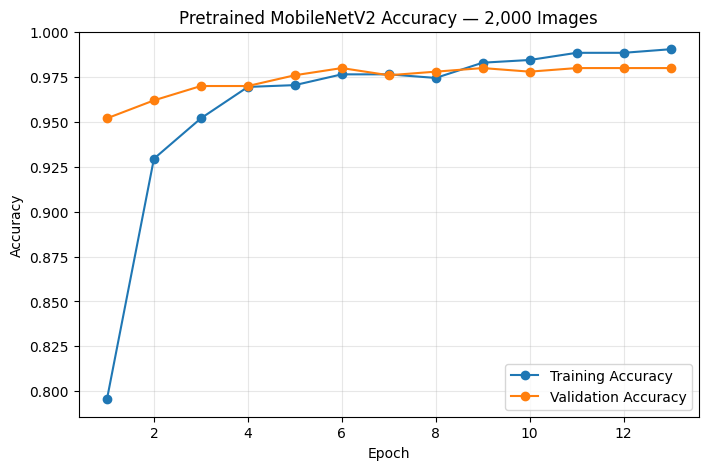

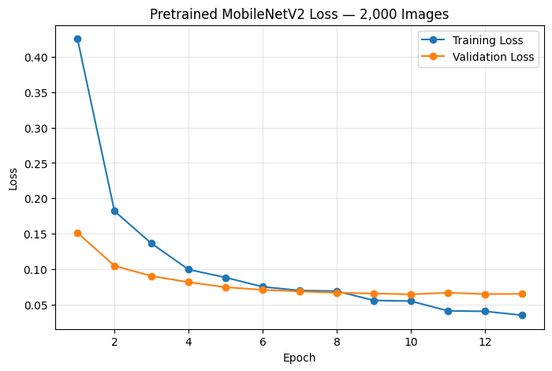

```python
# Step 37: Plot pretrained MobileNetV2 results for 2,000 images

pawprint_epochs_pretrained_2k = range(
    1, len(pawprint_history_pretrained_2k.history["accuracy"]) + 1
)

plt.figure(figsize=(8, 5))
plt.plot(
    pawprint_epochs_pretrained_2k,
    pawprint_history_pretrained_2k.history["accuracy"],
    marker="o",
    label="Training Accuracy"
)
plt.plot(
    pawprint_epochs_pretrained_2k,
    pawprint_history_pretrained_2k.history["val_accuracy"],
    marker="o",
    label="Validation Accuracy"
)

plt.title("Pretrained MobileNetV2 Accuracy — 2,000 Images")
plt.xlabel("Epoch")
plt.ylabel("Accuracy")
plt.legend()
plt.grid(alpha=0.3)
plt.show()

plt.figure(figsize=(8, 5))
plt.plot(
    pawprint_epochs_pretrained_2k,
    pawprint_history_pretrained_2k.history["loss"],
    marker="o",
    label="Training Loss"
)
plt.plot(
    pawprint_epochs_pretrained_2k,
    pawprint_history_pretrained_2k.history["val_loss"],
    marker="o",
    label="Validation Loss"
)

plt.title("Pretrained MobileNetV2 Loss — 2,000 Images")
plt.xlabel("Epoch")
plt.ylabel("Loss")
plt.legend()
plt.grid(alpha=0.3)
plt.show()
```

### Results and Interpretation — Pretrained CNN with 2,000 Images

The pretrained MobileNetV2 model trained with 2,000 images achieved a test accuracy of **96.60%** and a test loss of **0.1041**. This is substantially better than the CNN trained from scratch with 2,000 images, which achieved 71.20% test accuracy.

Compared with the pretrained model trained on 1,000 images, test accuracy increased slightly from 96.40% to 96.60%. This suggests that the pretrained model was already able to extract useful image features from the smaller dataset.

Training accuracy increased throughout the experiment, while validation accuracy reached 98.00%. Early stopping restored the model weights from Epoch 10, which had the lowest validation loss.

Overall, transfer learning produced strong classification performance with both dataset sizes, although the improvement from adding more training images was relatively small.

### Experiment 3: Pretrained MobileNetV2 Using 6,000 Training Images

This experiment evaluates the performance of MobileNetV2 using 6,000 training images, consisting of 3,000 cat images and 3,000 dog images. The pretrained feature-extraction layers remain frozen, and a new classification head is trained. The same validation and testing datasets are used for comparison with the previous experiments.

```python
# Step 39: Build MobileNetV2 for 6,000 training images

pawprint_base_6k = MobileNetV2(
    weights="imagenet",
    include_top=False,
    input_shape=(128, 128, 3)
)

pawprint_base_6k.trainable = False

pawprint_pretrained_cnn_6k = tf.keras.Sequential([
    pawprint_base_6k,
    tf.keras.layers.GlobalAveragePooling2D(),
    tf.keras.layers.Dense(128, activation="relu"),
    tf.keras.layers.Dropout(0.5),
    tf.keras.layers.Dense(1, activation="sigmoid")
])

pawprint_pretrained_cnn_6k.compile(
    optimizer=tf.keras.optimizers.Adam(learning_rate=0.0001),
    loss="binary_crossentropy",
    metrics=["accuracy"]
)

pawprint_pretrained_cnn_6k.summary()
```

```
Model: "sequential_6"
```

```
┏━━━━━━━━━━━━━━━━━━━━━━━━━━━━━━━━━┳━━━━━━━━━━━━━━━━━━━━━━━━┳━━━━━━━━━━━━━━━┓
┃ Layer (type)                    ┃ Output Shape           ┃       Param # ┃
┡━━━━━━━━━━━━━━━━━━━━━━━━━━━━━━━━━╇━━━━━━━━━━━━━━━━━━━━━━━━╇━━━━━━━━━━━━━━━┩
│ mobilenetv2_1.00_128            │ (None, 4, 4, 1280)     │     2,257,984 │
│ (Functional)                    │                        │               │
├─────────────────────────────────┼────────────────────────┼───────────────┤
│ global_average_pooling2d_2      │ (None, 1280)           │             0 │
│ (GlobalAveragePooling2D)        │                        │               │
├─────────────────────────────────┼────────────────────────┼───────────────┤
│ dense_12 (Dense)                │ (None, 128)            │       163,968 │
├─────────────────────────────────┼────────────────────────┼───────────────┤
│ dropout_6 (Dropout)             │ (None, 128)            │             0 │
├─────────────────────────────────┼────────────────────────┼───────────────┤
│ dense_13 (Dense)                │ (None, 1)              │           129 │
└─────────────────────────────────┴────────────────────────┴───────────────┘
```

```
 Total params: 2,422,081 (9.24 MB)
```

```
 Trainable params: 164,097 (641.00 KB)
```

```
 Non-trainable params: 2,257,984 (8.61 MB)
```

```python
# Step 40: Train pretrained MobileNetV2 with 6,000 images

pawprint_early_stop_pretrained_6k = tf.keras.callbacks.EarlyStopping(
    monitor="val_loss",
    patience=3,
    restore_best_weights=True
)

pawprint_history_pretrained_6k = pawprint_pretrained_cnn_6k.fit(
    pawprint_pretrained_train_ds_6k,
    validation_data=pawprint_pretrained_val_ds,
    epochs=15,
    callbacks=[pawprint_early_stop_pretrained_6k]
)
```

```
188/188 ━━━━━━━━━━━━━━━━━━━━ 22s 75ms/step - accuracy: 0.8995 - loss: 0.2378 - val_accuracy: 0.9540 - val_loss: 0.1098
188/188 ━━━━━━━━━━━━━━━━━━━━ 6s 32ms/step - accuracy: 0.9680 - loss: 0.0973 - val_accuracy: 0.9640 - val_loss: 0.0899
188/188 ━━━━━━━━━━━━━━━━━━━━ 6s 32ms/step - accuracy: 0.9693 - loss: 0.0819 - val_accuracy: 0.9760 - val_loss: 0.0800
188/188 ━━━━━━━━━━━━━━━━━━━━ 6s 32ms/step - accuracy: 0.9777 - loss: 0.0650 - val_accuracy: 0.9780 - val_loss: 0.0744
188/188 ━━━━━━━━━━━━━━━━━━━━ 6s 34ms/step - accuracy: 0.9808 - loss: 0.0576 - val_accuracy: 0.9800 - val_loss: 0.0714
188/188 ━━━━━━━━━━━━━━━━━━━━ 6s 32ms/step - accuracy: 0.9815 - loss: 0.0538 - val_accuracy: 0.9800 - val_loss: 0.0697
188/188 ━━━━━━━━━━━━━━━━━━━━ 6s 32ms/step - accuracy: 0.9855 - loss: 0.0459 - val_accuracy: 0.9820 - val_loss: 0.0672
188/188 ━━━━━━━━━━━━━━━━━━━━ 10s 31ms/step - accuracy: 0.9850 - loss: 0.0445 - val_accuracy: 0.9740 - val_loss: 0.0682
188/188 ━━━━━━━━━━━━━━━━━━━━ 6s 31ms/step - accuracy: 0.9877 - loss: 0.0365 - val_accuracy: 0.9740 - val_loss: 0.0684
188/188 ━━━━━━━━━━━━━━━━━━━━ 6s 32ms/step - accuracy: 0.9895 - loss: 0.0322 - val_accuracy: 0.9780 - val_loss: 0.0680
```

```python
# Step 41: Evaluate pretrained MobileNetV2 with 6,000 images

pawprint_pretrained_loss_6k, pawprint_pretrained_accuracy_6k = (
    pawprint_pretrained_cnn_6k.evaluate(pawprint_pretrained_test_ds)
)

print(f"Test Accuracy: {pawprint_pretrained_accuracy_6k * 100:.2f}%")
print(f"Test Loss: {pawprint_pretrained_loss_6k:.4f}")
```

```
16/16 ━━━━━━━━━━━━━━━━━━━━ 1s 74ms/step - accuracy: 0.9540 - loss: 0.1121
Test Accuracy: 95.40%
Test Loss: 0.1121
```

### Training and Validation Performance — 6,000 Images

The following graphs show the training and validation accuracy and loss of the pretrained MobileNetV2 model using 6,000 images.

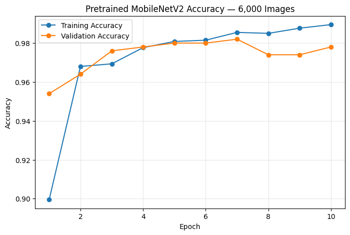

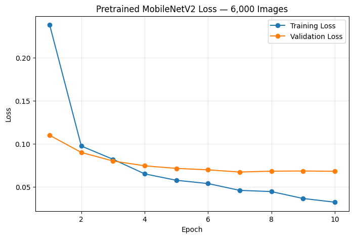

```python
# Step 42: Plot pretrained MobileNetV2 results for 6,000 images

pawprint_epochs_pretrained_6k = range(
    1, len(pawprint_history_pretrained_6k.history["accuracy"]) + 1
)

plt.figure(figsize=(8, 5))
plt.plot(
    pawprint_epochs_pretrained_6k,
    pawprint_history_pretrained_6k.history["accuracy"],
    marker="o",
    label="Training Accuracy"
)
plt.plot(
    pawprint_epochs_pretrained_6k,
    pawprint_history_pretrained_6k.history["val_accuracy"],
    marker="o",
    label="Validation Accuracy"
)

plt.title("Pretrained MobileNetV2 Accuracy — 6,000 Images")
plt.xlabel("Epoch")
plt.ylabel("Accuracy")
plt.legend()
plt.grid(alpha=0.3)
plt.show()

plt.figure(figsize=(8, 5))
plt.plot(
    pawprint_epochs_pretrained_6k,
    pawprint_history_pretrained_6k.history["loss"],
    marker="o",
    label="Training Loss"
)
plt.plot(
    pawprint_epochs_pretrained_6k,
    pawprint_history_pretrained_6k.history["val_loss"],
    marker="o",
    label="Validation Loss"
)

plt.title("Pretrained MobileNetV2 Loss — 6,000 Images")
plt.xlabel("Epoch")
plt.ylabel("Loss")
plt.legend()
plt.grid(alpha=0.3)
plt.show()
```

### Results and Interpretation — Pretrained CNN with 6,000 Images

The pretrained MobileNetV2 model trained using 6,000 images achieved a **test accuracy of 95.40%** and a **test loss of 0.1121**. This was substantially better than the CNN trained from scratch using 6,000 images, which achieved 79.60% test accuracy.

During training, accuracy increased to 98.95%, while the highest validation accuracy reached 98.20%. The lowest validation loss occurred at Epoch 7, and early stopping restored the model weights from that epoch.

Interestingly, the test accuracy was slightly lower than the pretrained models trained using 1,000 images (96.40%) and 2,000 images (96.60%). This indicates that increasing the training dataset size did not consistently improve test accuracy in these experiments. Differences in training dynamics, model initialization, and generalization may have contributed to this result.

Overall, transfer learning provided strong classification performance across all three dataset sizes, demonstrating the effectiveness of pretrained image features for cats-versus-dogs classification.

## Final Comparison of CNN Models

The following table compares the test performance of CNN models trained from scratch and pretrained MobileNetV2 models across the three training dataset sizes.

| Training Images | CNN From Scratch Accuracy | CNN From Scratch Loss | Pretrained MobileNetV2 Accuracy | Pretrained MobileNetV2 Loss |
| --- | --- | --- | --- | --- |
| 1,000 | 69.20% | 0.6888 | 96.40% | 0.1055 |
| 2,000 | 71.20% | 0.5902 | 96.60% | 0.1041 |
| 6,000 | 79.60% | 0.4339 | 95.40% | 0.1121 |

### Comparative Analysis

The CNN models trained from scratch showed an improvement in test accuracy as the number of training images increased. Accuracy rose from 69.20% with 1,000 images to 79.60% with 6,000 images. This suggests that the larger training datasets helped the models learn more useful visual features. However, the 1,000-image experiment used a different stopping strategy, so the results cannot be attributed entirely to dataset size.

The pretrained MobileNetV2 models achieved substantially higher test accuracy across all three dataset sizes. The highest test accuracy was **96.60%**, achieved using 2,000 training images. Although the 6,000-image pretrained model achieved slightly lower test accuracy, all three pretrained models performed strongly.

Overall, the experiments demonstrate that transfer learning can provide a substantial advantage over training a CNN from scratch, particularly when the available training dataset is relatively small.

## Conclusion

This assignment investigated the performance of convolutional neural networks (CNNs) for classifying cat and dog images using three different training dataset sizes: 1,000, 2,000, and 6,000 images.

Two approaches were evaluated: training a CNN from scratch and applying transfer learning using the pretrained MobileNetV2 architecture. All experiments used the same validation and testing datasets to support consistent evaluation.

The CNN models trained from scratch achieved test accuracies of 69.20%, 71.20%, and 79.60%, respectively. These results showed improved classification performance with larger training datasets in the experiments conducted.

The pretrained MobileNetV2 models achieved significantly higher test accuracies of 96.40%, 96.60%, and 95.40%, respectively. The best overall result was obtained using the pretrained model trained with 2,000 images, which achieved **96.60% test accuracy**.

Although increasing the number of training images generally improved the performance of the CNN models trained from scratch, the pretrained models did not show a consistent improvement with larger datasets. This highlights the importance of pretrained feature representations, model initialization, and training strategies.

Overall, the results demonstrate that transfer learning is an effective approach for image classification, particularly when working with limited training data. The experiments also emphasize the importance of evaluating models on unseen test data rather than relying only on training accuracy.